# US Flights in 2008 and comparisons with other years

## by Duc Vu

### The Dataset

1. **The main flight dataset.** It contains many variables of US flights for 1987-2008. Chosen for this project are flights information for five year intervals (1988, 1993, 1998, 2003, 2008). The main data analysis and visualisations will be conducted for the year 2008. The dataset can be obtained through the [Statistical Computing Statistical Graphics](http://stat-computing.org/dataexpo/2009/the-data.html).
2. **The carrier airline.** This provides the code and name of the airlines.
3. **The locations of origin and destination of flights.** These contain the International Air Transport Association (IATA), information about the airport, the city and state it is located in, and the latitude and longitude.

### The main features of the dataset

- `Year`
- `Month`
- `Day`
- `DayOfWeek`
- `DepTime` - actual depature time (local, in hhmm)
- `CRSDepTime` - scheduled departure time (local, in hhmm)
- `ArrTime` - actual arrival time (in hhmm)
- `CRSArrTime` - scheduled arrival time (local, in hhmm)
- `ActualElapsedTime` - actual flight elapsed time (in minutes)
- `CRSElapsedTime` - scheduled flight elapsed time (in minutes)
- `AirTime` - time of aircraft in air (in minutes)
- `ArrDelay` - arrival delay (in minutes)
- `DepDelay` - departure delay (in minutes)
- `Distance` - in miles
- `Cancelled` - was the flight cancelled?
- `CancellationReason` - reason for cancellation (carrier, weather, NAS, or security)
- `Diverted` - was the flight diverted?
- `CarrierDelay`, `WeatherDelay`, `NASDelay`, `SecurityDelay`, `LateAircraftDelay` - in minutes
- `Airline` - name of airline carrier,
- `Origin_city` and `Origin_state` - location of origin of flight
- `Dest_city` and `Dest_state` - location of origin of flight

#### `DayOfWeek`

**Are there more or fewer flights scheduled in a particular day of the week?**

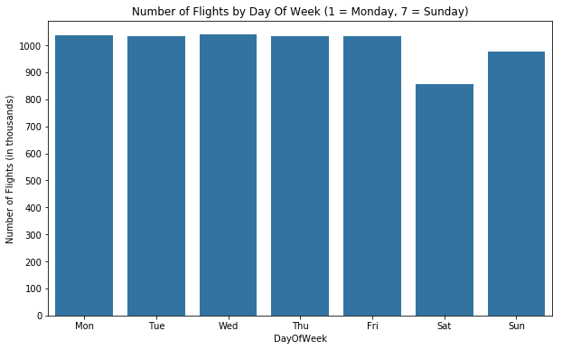

```python
fig = plt.figure(figsize = (10, 6))
sb.countplot(f2008_clean.DayOfWeek, color = base_color)

plt.title("Number of Flights by Day Of Week (1 = Monday, 7 = Sunday)")
plt.ylabel("Number of Flights (in thousands)")
ticks2 = np.array([n for n in range(0, 1001, 100)])
plt.yticks(ticks2 * 1000, ticks2)

# Get axis location to change to name of days of the week
ax = plt.gca().get_xticks()
plt.xticks(ax, ["Mon", "Tue", "Wed", "Thu", "Fri", "Sat", "Sun"]);
```

During the weekdays (Mondays to Fridays), the number of flights scheduled are very similar. On the weekends (Saturdays and Sundays), the number of flights are unusually lower, with Saturdays experiencing a significant dip (up to 17% lower compared with the average weekday).

This is rather unexpected as we may have expected a higher number of flights during weekends where people are more likely to go on short weekend holiday nearby. However, this is not the case. Could the higher volume of flights during weekdays be due to the increased travels of businessmen and businesswomen during weekdays, and very little on the weekends? Or could this be due to airlines which may set higher prices on the weekends, therefore lowering the demand and schedule fewer flights?

In addition, the lower number of flights on Saturday may be contributing to the steep drop seen from the first visualisation of number of flights by day.

#### `Distance` and `Airline`

**Do certain airlines favour short-haul or long-haul flights?**

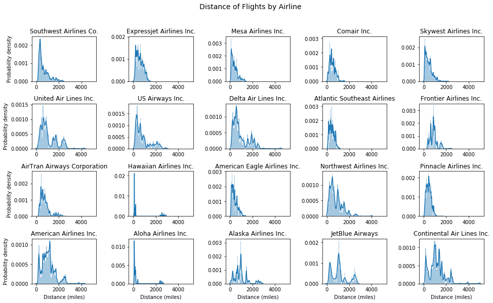

```python
airlines = f2008_clean.Airline.unique()
location = [i for i in range(1, 21)]

fig = plt.figure(figsize = (16, 9))
plt.suptitle("Distance of Flights by Airline", size = 14)

# Share axes with plot with highest values on axis
ax3 = plt.subplot(5, 4, 20)

# Create space between plots
fig.subplots_adjust(wspace = 0.5, hspace = 0.5)

for airline, loc in zip(airlines, location):
    ax = plt.subplot(4, 5, loc, sharex = ax3)
    airline_plot = f2008_clean[f2008_clean.Airline == airline]
    sb.distplot(airline_plot.Distance)
    plt.title(airline)
    plt.xlabel("")
    if loc >= 16:
        plt.xlabel("Distance (miles)")
    if loc % 5 == 1:
        plt.ylabel("Probability density");
```

There are some really interesting insights provided by these plots. Three are described below.

- Many airlines operate flights under 2000 miles, including Southwest Airlines Co., Expressjet Airlines Inc., Mesa Airlines Inc., Comair Inc., Skywest Airlines Inc., Atlantic Southeast Airlines, American Eagle Airlines Inc., and Pinnacle Airlines Inc.
- Both Hawaiian Airlines Inc. and Aloha Airlines Inc. have a pronounced bimodal peaks. The peaks at short distances correspond to flights between Hawaiian airports (e.g. Honolulu, Kahului, Lihue), and the peaks at distances above 2000 miles are flights to Californian cities (e.g. Santa Ana, Oakland, Sacramento). This is expected as Hawaii is an island far off the coast of the US, and either airlines will fly to another Hawaiian city or to mainland - thus showing the bimodal relationship.
- Several airlines operate many different routes at different distances shown by the multimodal peaks, such as United Air Lines Inc., Delta Air Lines Inc., American Airlines Inc., Alaska Airlines Inc., JetBlue Airways, and Continental Air Lines Inc.

#### `CarrierDelay` and `LateAircraftDelay` by `Airline`

**Which airlines have the best and worst delay record (due to airline's own responsibility) on average?**

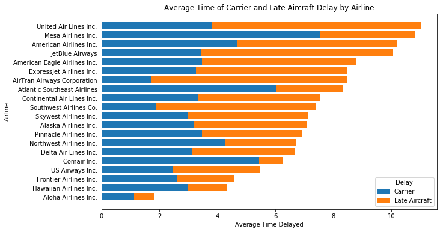

```python
plt.figure(figsize = (10, 6))

carrier_plot_avg = plt.barh(delay_airline_total.index, carrier_davg)
late_plot_avg = plt.barh(delay_airline_total.index, late_davg, left = carrier_davg)

plt.title("Average Time of Carrier and Late Aircraft Delay by Airline")
plt.xlabel("Average Time Delayed")
plt.ylabel("Airline")

plt.legend((carrier_plot_avg, late_plot_avg), ("Carrier", "Late Aircraft"), title = "Delay");
```

From the above plot, four airlines have an average of over 10 minutes delayed (in descending order of total average time): United Air Lines Inc., Mesa Airlines Inc., American Airlines Inc, and JetBlue Airways. Southwest Arilines Co. which previously shown the highest total time delayed does not have such a high average time delayed. Aloha Airlines Inc. has the best record of lowest average time of delays (under 2 minutes) due to carrier and late aircraft arrival.

This insight provides details about which airline has the highest and lowest efficiency when it comes to aircraft maintenance and schedule. Perhaps, this will allow customers to identify which airlines are more punctual, increasing the tickets bought at those airlines. The bad-performing airlines may use this to improve their delay records.

#### Number of flights throughout the `Year`

**How has the number of flight departures change with a 7-day moving average over the past 20 years (five year intervals between 1988-2008)?**

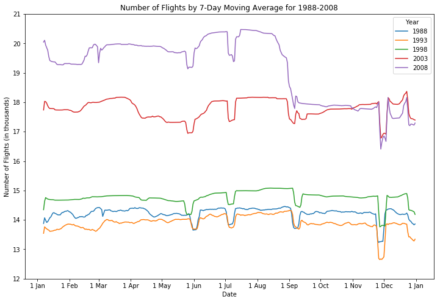

```python
plt.figure(figsize = (12, 8))

x = [i for i in range(1, 366)]

plt.errorbar(x, y = ma_1988_array, label = "1988")
plt.errorbar(x, y = ma_1993_array, label = "1993")
plt.errorbar(x, y = ma_1998_array, label = "1998")
plt.errorbar(x, y = ma_2003_array, label = "2003")
plt.errorbar(x, y = ma_2008_array, label = "2008")

plt.title("Number of Flights by 7-Day Moving Average for 1988-2008")
plt.xlabel("Date")
plt.ylabel("Number of Flights (in thousands)")
ticks30 = np.array([n for n in range (12, 22)])
plt.yticks(ticks30 * 1000, ticks30)
plt.legend(title = "Year");

plt.xticks([1, 32, 60, 91, 121, 152, 182, 213, 244, 274, 305, 335, 366],
           ["1 Jan", "1 Feb", "1 Mar", "1 Apr", "1 May", "1 Jun",
            "1 Jul", "1 Aug", "1 Sep", "1 Oct", "1 Nov", "1 Dec", "1 Jan"]);
```

Year 1993 has on average the lowest number of flights, followed by 1988 and then 1998. 2003 has the second highest number of flights and 2008 has the highest the number of flights scheduled. From 1998-2008, the number of flights have increased. Perhaps this could be due to flying becoming a more and more popular mode of transportation for travelling, especially with the advancements in technology in aircrafts, and cheaper air tickets.

There are several patterns visible. There is a small dip in flights at the end of May to the beginning of June, and at the beginning of July and September. There tends to be a signficant dip at the end of November and beginning of December for all years.

In 2008, the number of flights experience a huge fall from around mid-August compared with other years, which is uncharacteristic. This coincides with the financial crisis which started in September. Could this be the reason for the unexpected large fall in flights scheuduled?